# Draft Facebook API Report

paul

February 16, 2017

# **Next Steps:**

1: Replace the Tokens to a test user (DONE) 2: Think about how to extract personal information: + compare just in general + After your friend have accepted permissions to this facebook applications. 3: Think about segmenting searches + What parameters are avaiable for each of the functions + How would you go about sepcifiying geographical location + How would you track user information + **Probably will have to figure out how to parse the returned list**

# **Notes/Questions:**

- The entire process of extracting information can be simplified using `httr:GET()` and`httr: content(raw_URL_cotent,as="parsed")` The benefit of using Rfacebook, is that is provides clear documentation and organizes the output to data frames for direct data processing. Although the fields and information you can request is greatly reduced.
  - for example: the *callAPI* method handles the different *GET* parameters for different types of tokens. This function can be used to request any number of fields/edges. However a list is returned. In order to format the returned data into an organized data frame requires some manual coding.

# **Summary of Findings**:

- The application can not extract personnal information without permissions.
  - given a particular user ID, i have only managed to extract the username and the corresponding user Id.
- Public information such as posts, comments can be accessed.

# **Introduction to Facebook Graph API**

- The offical documentation is provided [here](https://developers.facebook.com/docs/graph-api)

## **Rate Limit:**

- [Rate Limit](https://developers.facebook.com/docs/graph-api/advanced/rate-limiting)
- Two main types of rate limits:
  - Application-Level Rate Limiting
  - Page-Level Rate Limiting
- [Automated Data Collection Terms](https://www.facebook.com/apps/site_scraping_tos_terms.php?hc_location=ufi)

### **Page-Level Rate Limiting:**

- These apply to calls made using a page access token.
  - app will recieve error code *32* if limits are hit.
- Limits imposed on each page rather than the app. Rate limiting tool on facebook provides information regarding page rate limits.
- A total call of 4800 calls per daily engaged user per 24 hours. If page has 100 daily users, then 480,000 calls can be made on behalf of the page in 24-hour period. The total calls is 480,000, not limited to each app. One app could make 480,000 requests.
- Any subsequent calls once the limit has been hit will result in errors being thrown.

### **Application-Level Rate Limiting:**

- Restricted to application acess token.
- Each application have a limit of 200 requests per hour for each user that uses the application.

```r
    ##Loading Libraries needed for the rest of the report:

    library(jsonlite)
    library(knitr)
    library(Rfacebook)
    knitr::opts_chunk$set(error=T,warning=TRUE)

    rm(list = ls())
```

# **Experimenting With Facebook Graph API Using Graph Explorer**

- [The Facebook Graph Explorer](https://developers.facebook.com/tools/explorer) is a convenient tool developed by Facebook that allows the user to easily explore the facebook API.
- This section outlines some of the results I noticed while playing around with the facebook API. I used my own personnal facebook to register as a developer.

## **Exploring the “user” rootNode:**

- the */me* ID is a special user id which indicates the local developer who is using the graph API Explorer.
- **The return type of any request seems to be in JSON format**
- Trying to extract basic information about **“me”**
  - the API version used is *v2.8*
  - The access token generated is set to include all permissions. The information I obtained is shown below:

```
## [[1]]
## [[1]]$name
## [1] "Paul Liu"
##
## [[1]]$id
## [1] "10207154569334139"
```

- if only */me* is typed in, the information returned depends on the security setting of the individual user.
- *Attempt to see if I can get Ids of my friends and get their friend list:*
  - 1 I used the edge *friendlists* to extract a list of my friend’s user IDs
    - `GET graph.facebook.com/me/friendlists`
  - 2 I then selected a random User ID and tried to extract further information.
  - 3 *However I am unable to extract further information using those Ids, not even basic information such as names. I am limited by the users who have given me permission to access their data. Thus it would appear that it will be diffcult to extract information via their own user Ids without proper permissions.*
1. **/friends** edge to extract a list of my friends, a warning message that stated: *“only friends who use the same app are returned”*
   - It is important to note
2. */likes* edge can extract all the pages that the user likes. The return is a JSON array of different facebook page names and the corresponding page IDs.
   - *Note: The complete list is not shown, to navigate to view more of the listed information, refer to the pagination style on [Using the Graph API](https://developers.facebook.com/docs/graph-api/using-graph-api)*
   - With the page IDs, I can gain limited access to the information on the public facebook pages, things like: “current location”, “description”, “fan_count”.
   - A more complete list is available at [Facebook API-Page](https://developers.facebook.com/docs/graph-api/reference/page/)
3. the field: *cover* returns a URL pointing to the cover photo of the user.
4. field: *group* returns list of facebook pages that the person is the admin of.

In general, most information requires proper authorization so that you can access the user’s personal information. Thus it would appears accessing the **“User”** root node is not sufficient for the purposes of data scraping unless you have permisison to acess their information. However, it could be interesting to use a user as a starting point and use edges to get access to other information could be beneficial.

For a more complete of possible fields/edges related to the **“User”** root node, refer to the [Facebook API Reference](https://developers.facebook.com/docs/graph-api/reference/user/).

## **Exploring the “Page” root node:**

- [Facebook API Reference - Page](https://developers.facebook.com/docs/graph-api/reference/page)
1. I started by going to a random facebook page: [Masterchef USA](https://www.facebook.com/masterchefusa/).
2. Using the URL of the above page and a **“Get”** request, I am able to obtain the **pageID: “150316218324753”** and the **pageName:“Masterchef USA”**
3. using this ID, I tried to access some of the fields:
   - *“about” field:* I recieved a string outlining what the page is about.
   - *“feed” edge:* returns the newsfeed on the page posted by non-admins.A limit of 100 messages/posts can be returned at a time. Thus if large amounts of data needs to be gathered, requests needs to be made to navigate the paging cursors.
     - With the *ids* of each posts returned, I can access the individual posts.
     - By nesting requests, you can also get the comments to show alongside the main message. `/{page-ID}/feed?fields=comments`
     - More information on **Nesting Requests**, refer to the “Nesting Requests” section in [Using API](https://developers.facebook.com/docs/graph-api/using-graph-api)
   - **“fan_count”field:** returns the number likes
- it is possible to extract insights, which outline statics regarding a page, but a lot of the functions only work with pages owned by the user.

### **Exploring “Application” root node:**

1. I started off by user the */me/achievements* edge to display some of the games I have played.
2. Then I opened the URL of the game in the browser and copied the displayed URL: _“[https://apps.facebook.com/texas_holdem/"_](https://apps.facebook.com/texas_holdem/%22_)
3. I posted the URL into a **Get** request on the explorer
   - `Get->/v2.8/https://apps.facebook.com/texas_holdem/`
4. The response includes: an object ID, basic descriptions, time of creation was returned. with no possiblity of accessing any further fields (since I do not own the application).

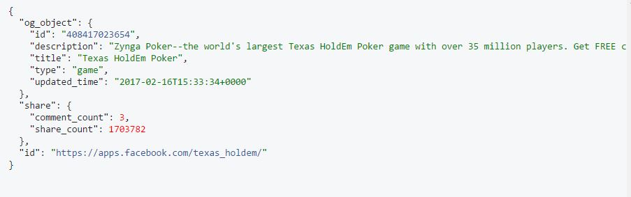

# **Exploring Rfacebook Pacakge:**

## **Basic Information:**

- [Documentation for Rfacebook](https://cran.r-project.org/web/packages/Rfacebook/Rfacebook.pdf)
- [Source Code on Github](https://github.com/pablobarbera/Rfacebook)

```r
# creating a folder under current working directory to store any data.

    if(!dir.exists("Rfacebook Exploration"))
    {
        dir.create("Rfacebook Exploration")
    }

    folder_Path  = "Rfacebook Exploration"

    rm(list = setdiff(ls(),c("folder_Path","token","FbObjectId") ))
```

## Creating Test Account:

- *First name:* Api-Testing
- *Last name:* nrc
- *Email:* NRC.API.Testing@gmail.com
- *Password:* NRCTesting123456!
- *Birthday:* July 1st 1997
- *Gender:* Males

## **Creating Long Lasting Authorization Token With *fbOAuth* Function:**

- Normally, a temporary access token normally has a 2 hour expiration time. A long-lived token(OAuth token) can be used for longer access. The following outlines how to obtain a long lived token:
  - __The *fbOAuth* function documentation outlines the steps.
  - [Mining Facebook Data Using R & Facebook API!](https://bigdataenthusiast.wordpress.com/2016/03/19/mining-facebook-data-using-r-facebook-api/) also provides steps to creating a long lived token. There is also some examples on functions in *Rfacebook*

### Steps:

1. Log in into [facebook developer website](https://developers.facebook.com/) and click **“Create App Button”** on the top right corner.
   - you will need to accept the [Facebook Plateform Policy](https://developers.facebook.com/policy/) and [Facebook privacy policy](https://www.facebook.com/about/privacy/).
2. I entered a name (NRC dataMining), my email and a random category and hit “create”
   - I clicked under *settings* with my app and I noteded dowm my **app id: 1353820787971442** and my **app secret:4841ab73f4f68960ebbf37e5705e2610**
3. Creating the long-lived access token using the *fbOAuth* method.The following steps are taken from the *Rfacebook documentation*
   - 1. Run the fbOAuth function with your “App ID” and “App Secret” as arguments. It will return a URL, which you will need to paste into the “Website with Facebook login” field in your App Settings on Facebook. Once you’ve done so, press Enter.
   - 2. After pressing enter, R will try to open a browser window to sign the token. If everything works well, you will get a message that says you can return to R. If not, try again in a few minutes to make sure your app had its settings updated properly.
   - NOTE: To ensure proper functioning of the “getInsights” function-family you will need to specify the exact permissions granted to your app. As this is (to our knowledge) currently not possible through the R based authentication process, please follow these steps:
   - Create App as mentioned above.
     - 1. Open the [Graph API Explorer](https://developers.facebook.com/tools/explorer/)
     - 2. Select your app in the upper right corner
     - 3. Click “Get Token”-> “Get Access Token”
     - 4. In the popup navigate to “Extended Permissions” and select “Insights”
     - 5. Confirm.
       - Ignore the following warning message (“Submit for Login Review…”) and confirm again.
     - 6. Go back to R and run fbOAuth with extended_permissions (still) set to FALSE. -> See 2nd step for possible messages concerning token creation.

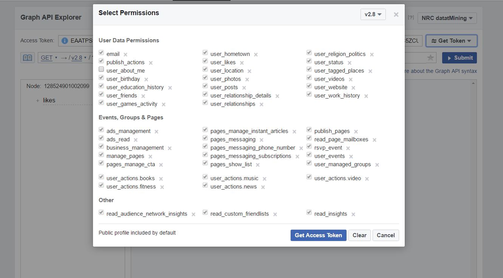

Extended Permissions

```r
    app_Id = 1353820787971442
    app_Secret = "4841ab73f4f68960ebbf37e5705e2610"

    ## The following shows the code that calls the fbOAuth function and creates the OAuth token, it has been commented once executed and the result is saved in a file called "my_OAuth.txt" Please run the following code in case the file does not exist.

   # token = fbOAuth(app_id = app_Id,app_secret = app_Secret,extended_permissions = TRUE)
   # if(!file.exists("My_OAuth"))
   #  {
   #      file.create("My_OAuth.txt")
   #      save(token, file= "My_OAuth.txt")
   #  }

load("My_OAuth.txt")
   rm(list = setdiff(ls(),c("folder_Path","token","FbObjectId") ))
```

## **The “CallAPI” function:**

- The “callAPI” function delegates the task of retriving information from the Facebook API to the *GET()* method in the *httr* pacakge and uses the *rjson* package to parse the returned json formated response.

### **Trying to extract my profile information:**

```r
##Extracting my personnal information
my_Data = callAPI("https://graph.facebook.com/me", token)
## Extracting my ID, this can be passed on as the ids for other functions
my_id = my_Data$id
print(my_Data)
```

```
## $name
## [1] "Api-Testing Nrc"
##
## $id
## [1] "128524901002099"
```

```r
##Adding fields to the URL to gain specific information (birthday, age_range)
#no spaces anywhere within the URL should be included
my_Specific_Information_Request = "https://graph.facebook.com/me?fields=birthday,age_range"
my_Specific_Data = callAPI(my_Specific_Information_Request,token)
print(my_Specific_Data)
```

```
## $birthday
## [1] "07/01/1997"
##
## $age_range
## $age_range$max
## [1] 20
##
## $age_range$min
## [1] 18
##
##
## $id
## [1] "128524901002099"
```

```r
## Trying to form nested levels of field requests. Gonna try to extract information regarding the "abouts" of the games I like

my_Games_Request= "https://graph.facebook.com/me?fields=games{about}"
my_Games = callAPI(my_Games_Request,token)
```

### **Extracting information about a public facebook page:**

```r
##Extracting facebook page basic information. The url of the page is: https://www.facebook.com/harrypottermovie/


    harry_Potter_Request = "https://graph.facebook.com/https://www.facebook.com/harrypottermovie/"
    Harry_Potter_Page = callAPI(harry_Potter_Request,token=token)
    print(Harry_Potter_Page)
```

```
## $name
## [1] "Harry Potter"
##
## $id
## [1] "156794164312"
```

```r
    ##Trying to extract other fields as well using the callAPI function
    harry_Potter_More = paste("https://graph.facebook.com",Harry_Potter_Page$id,"posts?fields=message",sep="/")
    information = callAPI(harry_Potter_More,token=token)
    names(information)
```

```
## [1] "data"   "paging"
```

```r
    class(information)
```

```
## [1] "list"
```

```r
    length(information$data)
```

```
## [1] 25
```

- **NOTE: the callAPI does not convert the returned information into a dataframe and other easily processed format. It is hard for me to extract the *messages* information**

### **Extracting informaiton about a comment to a post**:

```r
## Extracing information about a post/comment: URL of comment to a post:     https://www.facebook.com/bbcnews/posts/10154388838082217?comment_id=10154388923362217&comment_tracking=%7B%22tn%22%3A%22R0%22%7D
#     This was obtained by clicking on the "time stamp"  of a facebook post. NOTE: the comment URL also contains the original post URL, which in this case is: https://www.facebook.com/bbcnews/posts/10154388838082217

    comment_URL = "https://www.facebook.com/bbcnews/posts/10154388838082217?comment_id=10154388923362217&comment_tracking=%7B%22tn%22%3A%22R0%22%7D"


    comment = callAPI(comment_URL,token = token)
```

```
## Error in rjson::fromJSON(rawToChar(url.data$content)): unexpected character '<'
```

- Notes:
  - An error message is returned when *callAPI* request was made to a URL of a comment to a post. The error stated: **“Error in rjson::fromJSON(rawToChar(url.data$content)): unexpected character ‘<’”**
  - It turns out that the facebook API does not support a direct call to the information about comments via the URL. I attempted it as well on the [facebook Graph API Explorer](https://developers.facebook.com/tools/explorer/). The returned data was information regarding the post itself instead of the comment.

### **Developing a function to extract the “ID” of facebook object through using the URL of the object:**

```r
## ONLY VALID for SIMPLE Webaddresses with no id in the URL, ex: www.facebook.com/harrypotter

    FbObjectId = function(object_URL,token)
    {
        beginning_Index = 1
        # Checking the formating of the "object_URL"
        if(class(object_URL)!= "character"){
            warning("Object_URL is not a string")
        }else if( grep(pattern = "(http|https)://www.facebook.com(/.*)*", x=object_URL)!= beginning_Index ) {

             warning("Invalid URL")
        }

        #formating and checking the complete URL request to the facebook Graph API
        complete_URL = paste("https://graph.facebook.com",object_URL,sep = "/")
        #print(complete_URL)

        #Extracting the ID of the facebook object
        url_Data = Rfacebook::callAPI(complete_URL,token)
        url_id = url_Data$id

        # If the Id is not numeric, something is wrong.
        if(length( grep(pattern="www.facebook.com",x=url_id))!=0 ) {
              warning("Error In Returned ID: Not numeric values. URL likely not supported.")
        }

      url_id
    }
```

- Test cases:

```r
    ## For URLs that yield no ids, the facebook would return a version of the URL address as the object ID.(just discovered)

    ## A URL of a post on the public facebook page Harry Potter
    test1 = "https://www.facebook.com/harrypottermovie/photos/a.422515109312.180796.156794164312/10155042492264313"
    original_Return = "https://www.facebook.com/harrypottermovie/photos/a.422515109312.180796.156794164312/10155042492264313: https://www.facebook.com/harrypottermovie/photos/a.422515109312.180796.156794164312/10155042492264313"
    new_Return = "Error in FbObjectId(test1, token) : Error In Returned ID: Not numeric values. URL likely not supported."

    FbObjectId(test1,token)
```

```
## [1] "https://www.facebook.com/harrypottermovie/photos/a.422515109312.180796.156794164312/10155042492264313"
```

```r
    ## A comment on a public page
    test2 = "https://www.facebook.com/harrypottermovie/photos/a.422515109312.180796.156794164312/10155042492264313/?type=3&comment_id=10155042702764313&comment_tracking=%7B%22tn%22%3A%22R4%22%7D"
    FbObjectId(test2,token)
```

```
## [1] "https://www.facebook.com/harrypottermovie/photos/a.422515109312.180796.156794164312/10155042492264313/"
```

```r
    ## A URL of a public facebook page
    test3 = "https://www.facebook.com/harrypottermovie"
    FbObjectId(test3,token)
```

```
## [1] "156794164312"
```

```r
    ## A URL of a person's timeline (not my own)
    test4 = "https://www.facebook.com/FSXAC"
    FbObjectId(test4,token)
```

```
## [1] "https://www.facebook.com/FSXAC"
```

```r
     rm(list = setdiff(ls(),c("folder_Path","token","FbObjectId") ))
```

### **Conclusion:**

- the *callAPI* function allows you to call API using the GET methods using regular Facebook Query format. Its weakness is that it does not organize the information returned. **A potential new addition is to reference the source code to come with a way to better organize the returned JSON files into data frames**

## **Exploring *getPage,getPost,getCommentReplies*:**

- *GOAL: To extract information regarding comments on a public facebook webpage*

### **Steps Taken To Extract Comment:**

#### 1. Get the comments from BBC webpage posts (posts made by BBC) using **manual coding:**

```r
#Extracting the BBC webpage ID: (feels like this should be my own function.)

    facebook_API_URL = "https://graph.facebook.com"
    BBC_URL = "https://www.facebook.com/bbcnews"

    BBC_Id = FbObjectId(BBC_URL,token)
    print(BBC_Id)
```

```
## [1] "228735667216"
```

```r
#Now I can specify the "Edge" parameter of the Get query through placing "/posts"
    posts_Query = url <- paste0("https://graph.facebook.com/", BBC_Id, "/posts?fields=from,message,created_time,type,link,story,comments.summary(true)",
        ",likes.summary(true),shares")

    posts= callAPI(posts_Query,token)
    class(posts$data)
```

```
## [1] "list"
```

```r
    # at this stage, I am having trouble "subsetting" this list into more mangeable chunks: IE: have each individual post divided according to individual posts.It is currently outside my knowledge level to further subset this lists of elements. Such the pre-build pacakge is better because it organizes the information into dataframes.
```

#### 2. Get the comments using the Rfacebook pacakge()

```
1:  Starting with getting the post_Ids (mainly post Ids) using _getPage_
```

```r
    ## the getPage function returns a matrix, and one of the columns is the "postId"
    page_Information = getPage(BBC_Id,token,n=2)
```

```
## 2 posts
```

```r
    class(page_Information)
```

```
## [1] "data.frame"
```

```r
    dim(page_Information)
```

```
## [1]  2 11
```

```r
    names(page_Information)
```

```
##  [1] "from_id"        "from_name"      "message"        "created_time"
##  [5] "type"           "link"           "id"             "story"
##  [9] "likes_count"    "comments_count" "shares_count"
```

```r
    post_Ids = page_Information$id
```

```
2:  Getting information about each post using _getPost_ (mainly interested in comment ids)
```

```r
    ## trying to see getPost can be vectorized, it appears to be working through the use of lapply

    ## The return type is a list of posts and each element within this represents the information for     a single post. Each "post" is a list composed of three sections: "post","likes","comments".

    post_Information = lapply(post_Ids,getPost,n=100,token=token)

    names(post_Information[[2]])
```

```
## [1] "post"     "likes"    "comments"
```

```r
    ### for a single post_Id, the get post function behaves as expected
    single_Post = getPost(post_Ids[[2]],n=100,token=token)
    names(single_Post)
```

```
## [1] "post"     "likes"    "comments"
```

```r
    class(single_Post)
```

```
## [1] "list"
```

```r
    head(single_Post[["comments"]]$id)
```

```
## [1] "10154458029957217_10154458041032217"
## [2] "10154458029957217_10154458044072217"
## [3] "10154458029957217_10154458036572217"
## [4] "10154458029957217_10154458039427217"
## [5] "10154458029957217_10154458039197217"
## [6] "10154458029957217_10154458036202217"
```

```
3:  Now that I have obtained a list of comments, I can use the _getCommentReplies_ to further investigate each reply to a comment.
```

```r
## Somehow the following was deprecated. Not sure why

    ## I have extracted the list of comments_Id from the post_information
    ## the "comments" is a data frame where the column "id" represents the list of comments to the posts and each element within this "id" is another list of comment_ids.
    ## I have printed out such a comment Id below (note, I had to subset the list twice).

    comments = unlist( lapply(post_Information, function(x) {x["comments"]}), recursive = F)
    comments_Id = unlist(comments[[1]]["id"])


    #Extracting the comment replies to each posts' comments

    ## The following returns an unexpected error, because the facebook API throughs an error:
    ## "Unsupported get request. Object with ID '10154406740582217_10154386779424205' does not exist, cannot be loaded due to missing permissions, or does not support this operation.

    #The following reported facebook error
    #single_Comment_Reply = getCommentReplies(comments_Id[[1]][[1]],token=token)

    single_Comment_Reply2 = getCommentReplies(comments_Id[[1]],token=token)
    names(single_Comment_Reply2)
```

```
## [1] "comment" "replies"
```

#### What if the posts are pictures?

- The information regarding attachments (such as photos and videos) can be accessed using the *attachments* edge. However the Rfacebook pacakge does not seem to have explitict functions that support the extraction of information regarding attachments. This could be an area of further investigation.
- One way to extract this information is to use the *callAPI* method with the *attachments* edge specified as part of the query. However a method for successfully parsing and re-formating the returned output (list) into an organized data frame becomes the main issue at hand. One idea is to further investigate the source code of the *Rfacebook* pacakge, especially in the [utils.R package](https://github.com/pablobarbera/Rfacebook/blob/master/Rfacebook/R/utils.R) to see how previous developers have parsed the JSON information into a data frame.

## **Exploring *searchGroup & getGroup* functions:**

- *GOAL: To extract information regarding a public facebook group: [couponboutique](https://www.facebook.com/groups/couponboutique2/) using the getGroup function*

1: Suppose the ID is not known, or not certain. *searchGroup()* can be used to extract the group_Id:

```r
    group_Name = URLencode("The Coupon Boutique")
    group_Id = searchGroup(group_Name,token=token)
    print(group_Id)
```

```
##                                 name privacy               id
## 1 The Coupon Boutique - Public Group    OPEN 1696255650601823
## 2                The Coupon Boutique  CLOSED 1504395996479976
## 3 The Coupon Boutique - Public Group    OPEN 1580411485549988
```

```
+   An attempted solution found on [Stackoverflow](https://github.com/pablobarbera/Rfacebook/issues/7). Try to use _URLencode_ function to encode the name to in URL format.
```

```r
    group_Name_URL = URLencode("The Coupon Boutique")
    group_Id2 = searchGroup(group_Name_URL,token=token)
    class(group_Id2)
```

```
## [1] "data.frame"
```

```r
    print(group_Id2)
```

```
##                                 name privacy               id
## 1 The Coupon Boutique - Public Group    OPEN 1696255650601823
## 2                The Coupon Boutique  CLOSED 1504395996479976
## 3 The Coupon Boutique - Public Group    OPEN 1580411485549988
```

```
+   This solution appears to be working. Upon reading the documentation, it did specifcy that the name needs to be in "URL"
```

2: Extracting information using *getGroups*

```r
    start_Time = as.numeric(as.POSIXct("2016-12-01"))
    id = group_Id2$id[[1]]
    #I have verified that this id is linked with the URL for the group I have shown at the beginning of this section.
    print(id)
```

```
## [1] "1696255650601823"
```

```r
    #NOTE: the "groupId" is different from the "pageId" where the group is posting and hosting.

    #NOTE: the default number of posts to return is 25.
    group_posts = getGroup(id,token=token)
```

```
## 25 posts
```

```r
    class(group_posts)
```

```
## [1] "data.frame"
```

```r
    names(group_posts)
```

```
##  [1] "from_id"        "from_name"      "message"        "created_time"
##  [5] "type"           "link"           "id"             "story"
##  [9] "likes_count"    "comments_count" "shares_count"
```

```r
    rm(list = setdiff(ls(),c("folder_Path","token","FbObjectId") ))
```

## **Exploring *searchPage*:**

```r
    keyword ="Apples"
    data = searchPages(keyword,token, n=100)
```

```
## 100 pages
```

```r
    class(data)
```

```
## [1] "data.frame"
```

```r
   names(data)
```

```
##  [1] "id"                  "about"               "category"
##  [4] "description"         "general_info"        "likes"
##  [7] "link"                "city"                "state"
## [10] "country"             "latitude"            "longitude"
## [13] "name"                "talking_about_count" "username"
## [16] "website"
```

```r
   tail(data,n=2)
```

```
##                  id
## 99     121912944882
## 100 446127592110025
##                                                                                                                                 about
## 99  Pink Lady America is based in Yakima, WA.  We promote a fun and healthy lifestyle that is what the Pink Lady® brand is all about.
## 100                                                               The Official Page for the Washington Apple Commission - Middle East
##                    category
## 99                  Company
## 100 Food & Beverage Company
##                                                                                                                                                                                                                                                                                                          …
## 99                                                                                                                                                                                                                                                                                                       …
## 100 The Washington State Apple Advertising Commission was created by an act of the Washington State Legislature in 1937 at the request of the apple industry, making it one of the oldest and largest commodity commissions in the United States.\n\nUnder statutory authority, the Commission collects a…
##     general_info                likes
## 99          <NA> MjMxNzIwNDk2ODQzOTU0
## 100         <NA> MTMzNDYzMzc2Njc2ODAx
##                                                                                                                                                          link
## 99                                                                                                                  https://www.facebook.com/pinkladyamerica/
## 100 https://www.facebook.com/Washington-Apples-Middle-East-تفاح-واشنطن-446127592110025/
##       city state       country latitude longitude
## 99  Yakima    WA United States       NA        NA
## 100   <NA>  <NA>          <NA>       NA        NA
##                                                                                                                name
## 99                                                                                          Pink Lady® brand Apples
## 100 Washington Apples Middle East تفاح واشنطن
##     talking_about_count        username                 website
## 99                  104 pinkladyamerica www.pinkladyamerica.org
## 100                  46            <NA>      www.bestapples.com
```

```r
   rm(list = setdiff(ls(),c("folder_Path","token","FbObjectId") ))
```

## **Trying *getLikes*:**

- *GOAL:The documentation stated that it could provide information about a user or a page’s likes given the id. I want to see if it works with user Ids that have been granted permissions to my application.*

```r
    rm(list = setdiff(ls(),c("folder_Path","token","FbObjectId") ))
    user_Id =313298645491893

    # The following produces facebook error message:
    #likes = getLikes(user_Id,token=token)

    rm(list = setdiff(ls(),c("folder_Path","token","FbObjectId") ))
```

- Result, a random user who has been given permission to your application will result a facbeook error.

```r
    ##trying to see if I can get information about the test account's likes.
    ## It would appear that this function is not useable for my own personnal account. It also returns a facebook error. So this means
    my_Id = 128648664323056
    # likes = getLikes(my_Id,token=token)
    rm(list = setdiff(ls(),c("folder_Path","token","FbObjectId") ))
```

```r
    page_Id = 156794164312
    page_Likes = getLikes(page_Id,token=token)

    ##This works as it should.
```

## **Exploring *GetUsers*:**

- _**GOAL: To see if it is possible to extract information about general users**

```r
    ##List of Ids obtained from a public page's posts' comments.
    list_Of_Id = c("885385688153798","313298645491893","617647818354222","10202298838257102")

    #user_Info = getUsers(users = list_Of_Id, token=token, private_info = T)

    ##Example Listed in the documentation:
    user_Info_Self = getUsers("me",token=token)

    ##Perhaps the issue is that the private_info parameters needs to be false
    # user_Info3 = getUsers(users=list_Of_Id,token=token)
   rm(list = setdiff(ls(),c("folder_Path","token","FbObjectId") ))
```

- **Conclusion:** It appears that the _getUser_function does not seem to work either.

## **Methods that could be useful (not yet talked about):**

- *getReactions* which returns total amount of reactions to a post/posts (Sentiment analysis??)
- *getUsers* which retrieves public information about one or more Facebook users.Applicable to pages, if pageIds were entered instead (need to try)

## **List of Functions that have been limited due to V2.0 of Facebook API:**

- going to learn how to make tables.[knitr::kable](https://www.rdocumentation.org/packages/knitr/versions/1.15.1/topics/kable)

| functions | description |
| --- | --- |
| getCheckins | deprecated |
| getFQLS | deprecated |
| getFriends | only your friends who uses your application |
| getNetwork | only applicable to users of your application |
| searchFacebook | deprecated |

## **Summary of *Rfacebook*:**

| Advantages | Disadvantages |
| --- | --- |
| Clear documentation | Assumes that the data being searched for exists. If an error is thrown by the Facebook API, the search stops |
| High level of Abstraction, so no need to worry about the specifics | Some functions are no longer supported due to upgraded Facebook API |
| Good variety of functions that can provide data for data mining | Limited fields and edges, does not support the extraction of any number of fields and edges |

# Customizing Searches (Geographical Location, Users, Keywords etc)

## **List of Customizable Parameters Within the Rfacebook Package:**

### *getPage*:

- The bulit in package allows to specifiy the time period to extract information of the particular page by specifiying the since and until parameters(based on time of updates).
- Does not support parameters that allows filtering of information on a page other then the time stamp of update.

### *getPost*:

- Does not have parameters that allows you to filter the output (based on likes, based on geographical location etc) except to have extra information returned.
- The return is a list with 3 components: *posts, likes and comments*.
  - *post:*
    - author, creation date, id, count of like , comments and shares.
  - *likes:*
    - name of all users’ facebook ID that liked the post.
  - *comments:*
    - message, creation time, id, author.

### *searchPage*:

- returns location information (city names, coordinates) on webpages if it is made available to the public.
- Also returns “category” information if available, which can be helpful to filter information.

## *Location:*

*GOAL: To try and explore what the facebook api offer regarding extracting location information.*

### Exploring Facebook API for Nodes that Contain Location Information:

#### *Albums:*

- Contains a *location* field. It is the “The textual location of the album.” **Note, for general data collection, only public albums can be accessed with any access token.**
- The documentation is [here](https://developers.facebook.com/docs/graph-api/reference/v2.8/album/)
- I tried it on the [Masterchef Timeline Album](https://www.facebook.com/pg/Masterchef/photos/?tab=album&album_id=148022941877464) + the *location* field returned no information on the facebook graph explorer. + the album id is marked in the URL.`album_id=148022941877464`.
- Often the *location* field returns null.

#### *Comments:*

- Does not provide a location field.
- [Comments Documentation](https://developers.facebook.com/docs/graph-api/reference/v2.8/comment/)

#### *Events:*

- [Events Documentation](https://developers.facebook.com/docs/graph-api/reference/event/)
- Provides a *place* field which outlines the location of the event.
- Only public events
- Example:
  - URL: `https://www.facebook.com/events/175802919572863/`.
  - Event Id: `175802919572863`

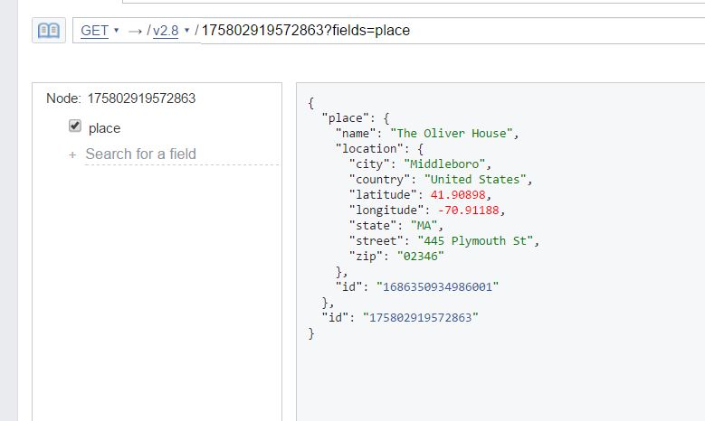

Return from Facebook API Explorer

#### *Pages:*

- *Pages* have a *location* field. This field is automatically returned, if available, as part of the *Rfacebook’s searchPage* function.

#### *Posts:*

- Might have location assoicated with the post under the *place* field.
- [Page Documentation](https://developers.facebook.com/docs/graph-api/reference/v2.8/post/)
- The URL for the post is: `https://www.facebook.com/DonaldTrump/photos/a.488852220724.393301.153080620724/10158714687065725/?type=3&comment_id=10158714702225725&comment_tracking=%7B%22tn%22%3A%22R0%22%7D`.
  - The Post Id is part of URL. The id is: `10158714687065725`.
- The *getPost* function in Rfacebook does not provide the *place* information.

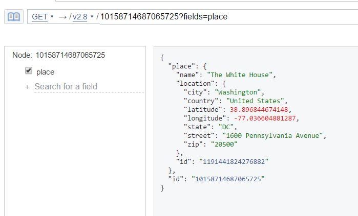

Post API Explorer Return

#### *Photos:*

- Also has a *place* field to indicate any location information.
- [Photos Documentation](https://developers.facebook.com/docs/graph-api/reference/photo/)

## Custom Parser

_**GOAL: to be able to parse the returned JSON formatted array for any aribitary request**

### Trying to understand the Returned Parsed information:

```r
 rm(list = setdiff(ls(),c("folder_Path","token","FbObjectId") ))
    post_Id = "10158714687065725"

## Specifying that the field I want is the place field
    request = paste("https://graph.facebook.com/",post_Id,"?fields=place",sep="")
    content = callAPI(url=request, token=token)
    ###content$place$name

## General information
    request2 = paste("https://graph.facebook.com/",post_Id,"?fields=place,picture,link",sep="")
    content2 = callAPI(url=request2, token=token)
    ###content2

#For simple requests, it would appear appear that the return format is nicely denoted and seperated via "$" Want to seperate into a column of information.

    unlisted = unlist(content2,use.names=T,recursive=F)
    length(unlisted)
```

```
## [1] 6
```

```r
    unlisted
```

```
## $place.name
## [1] "The White House"
##
## $place.location
## $place.location$city
## [1] "Washington"
##
## $place.location$country
## [1] "United States"
##
## $place.location$latitude
## [1] 38.89684
##
## $place.location$longitude
## [1] -77.0366
##
## $place.location$state
## [1] "DC"
##
## $place.location$street
## [1] "1600 Pennsylvania Avenue"
##
## $place.location$zip
## [1] "20500"
##
##
## $place.id
## [1] "1191441824276882"
##
## $picture
## [1] "https://scontent.xx.fbcdn.net/v/t1.0-0/s130x130/17021433_10158714687065725_1631653355169532126_n.jpg?oh=25ffd173ab0b8a9b670fb0111c07f688&oe=5932125A"
##
## $link
## [1] "https://www.facebook.com/DonaldTrump/photos/a.488852220724.393301.153080620724/10158714687065725/?type=3"
##
## $id
## [1] "10158714687065725"
```

```r
# Appears that the unlisted function automatically splits the elements into a list
```

### Experimenting with JSONlite

```r
    orignal = jsonlite::toJSON(content2)
    orignal
```

```
## {"place":{"name":["The White House"],"location":{"city":["Washington"],"country":["United States"],"latitude":[38.8968],"longitude":[-77.0366],"state":["DC"],"street":["1600 Pennsylvania Avenue"],"zip":["20500"]},"id":["1191441824276882"]},"picture":["https://scontent.xx.fbcdn.net/v/t1.0-0/s130x1…
```

```r
    simplifed = jsonlite::fromJSON(orignal,simplifyDataFrame = T)
    length(simplifed)
```

```
## [1] 4
```

```r
    class(simplifed)
```

```
## [1] "list"
```

```r
    ##Does not return the expected data frame
```

### Experimenting with tidyJSON

- [Tutorial](https://cran.r-project.org/web/packages/tidyjson/vignettes/introduction-to-tidyjson.html

```r
    library(tidyjson)
    library(dplyr)
    ## Converting the list into a dataframe
    #y=as.tbl_json(toString(content2))


    ##Trying to re-use fromJSON
    x=jsonlite::fromJSON(jsonlite::toJSON(content2[[2]]),simplifyVector = F)
    class(x)
```

```
## [1] "list"
```

```r
    ## In general, it would appear you would have to parse into a dataframe by ourself. The reason why jsonlite returns a list is due to the multiple levels of nesting for the location field.
```

### Making Function:

```r
    # Purpose: To extract the field information and divide return into a seperated list where each element correspondes to the first level fields' information.

    ExtractList = function(query,token)
    {
        unlist(
            callAPI(url=query,token=token),
            recursive = F,
            use.names = T
        )
    }


#finding the minimum number of rows
    MinRow=function(list)
    {
        min_Row= min( as.numeric(lapply(list,function(x) length(x)) ) )
    }


    #Purpose: To format the list into a rough Data Frame:
    #Assumptions: The nested elements are in the format of a list

    RoughDF = function(list){
    ## will just get the first level down
        data_Frame <-data.frame()

         if(length(list)==1)
        {
            data_Frame<-data.frame(list)
        }else if(length(list)==0 || is.null(list))
        {
            data_Frame=data.frame()
        }else if(length(list)>=2)
        {
             ##organizing first level into a matrix
            data_Frame = cbind(list[names(list)[1]], list[names(list)[2]] )

            if(length(list)>2)
            {
                for( i in 3:length(list) )x
                {
                    data_Frame = cbind(data_Frame,list[names(list)[i]])

                }
                colnames(data_Frame)= names(list)


                # ## initiating recursion to get the other levels parsed
                # for(i in names(list))
                # {
                #
                #     if( class(list[i]) =="list" )
                #     {
                #         data_Frame[,i]=RoughDF( unlist(recursive = F, list[i]) )
                #     }
                #
                # }
            }

        }

       data_Frame

       ## I have managaged to get the first level working. However problems would arrive if there are more than 1 row. It becomes hard to parse. THe idea behind this is that everythign will be stored as matrixes until the information is made available.

    }
```

- After experimentation, I realized that this method would not work. This is because you cannot append dataframes that are of a different dimension to existing data frames. The main idea behind this function was to first seperate the query information based on each fields, combine the fields into a data frame of 1 row and then append a data frame containing the details of the fields into the 1 row data frame.
- However due to the fact that each field contains arbitary number of details.
  - EX: `data field: id, message, etc VS id field: id`. Organizing the details into a data frame produces different dimensions of data frames compared to the original.

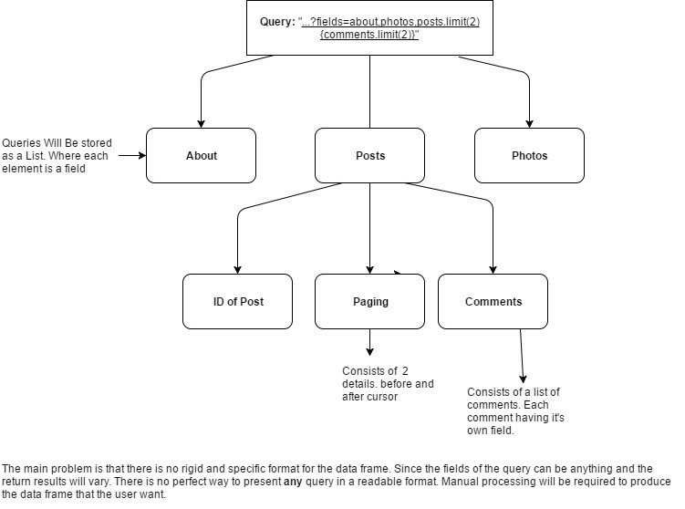

Processing Query Chart

- I have concluded to give up on this process.

```r
#Testing:
 rm(list = setdiff(ls(),c("folder_Path","token","FbObjectId","ExtractList","RoughDF","MinRow","UnravelList") ))

    page_Url= "https://www.facebook.com/harrypottermovie/"
    page_Id = FbObjectId(object_URL=page_Url, token=token)
    query = paste("https://graph.facebook.com/",page_Id,"?fields=posts.limit(10)",sep="")

    return = ExtractList(query,token)

    ## Calculating required data frame row number, should be the minimum length
    y=data.frame( seq(1:MinRow(return)) )
    names(y)= "test"
```

# **Search API:**

- Allows public searches on public information.
- [Search Documentation](https://developers.facebook.com/docs/graph-api/using-graph-api/v2.0#search)
- **This API provides the same functionality as facebook’s Search Bar.**
- Query example: `https:graph.facebook.com/search?q={string to search for}&type={type name}&{fields of type}`
- Allows:
  - [users](https://developers.facebook.com/docs/graph-api/reference/user/)
  - [page](https://developers.facebook.com/docs/graph-api/reference/page/)
  - [place-topic](https://developers.facebook.com/docs/graph-api/reference/place-topic/)
  - [event](https://developers.facebook.com/docs/graph-api/reference/event/)
  - [group](https://developers.facebook.com/docs/graph-api/reference/v2.8/group/)
  - [places](https://developers.facebook.com/docs/graph-api/reference/place/)